# Machine Learning: Mathematical Theory and Applications

#### 💪 Problem 4.2

Add time series effects to your model by including some lagged values of the response as features. Use the first four hourly lags of `log_cnt` plus the 24th hourly lag as features, in addition to all other features in Problem 3.1. Fit the model using an L1 regularisation and find the optimal $\lambda$ by applying the one-standard deviation rule when cross-validating the training data using 10 folds. Compute the RMSE (using the optimal $\lambda$) for the training and test data and compare to Problem 3.1. Are the residuals from this new model more adequate?

**Tip**

The function `mutate()` from the `dplyr` package is useful for adding columns to a data frame. Moreover, the function `lags(x, k)` lags the time series `x` by `k` steps.

Notice that some observations are lost when lagging, i.e. `NA` values are introduced. You can remove these observations from the dataset.

```r
suppressMessages(library(dplyr))

#=== 1. Prepare data
  #--- Combine train + test log_cnt
  #combined_data <- bind_rows (bike_alldata_train, bike_alldata_test)
  #--- Create lagged features and add to the full data set
  combined_data <- bike_data %>% arrange (as.Date(dteday), hr) %>%
    mutate (log_cnt_lag1 = lag(log_cnt, 1), #lag 1 hour
          log_cnt_lag2 = lag (log_cnt, 2), #lag 2 hour
          log_cnt_lag3 = lag (log_cnt, 3), #lag 3 hour
          log_cnt_lag4 = lag (log_cnt, 4), #lag 4 hour
          log_cnt_lag24 = lag (log_cnt, 24)) #lag 1 day

  #--- Split back to train and test data
  bike_data_train_lag <- combined_data %>% filter(dteday >= as.Date("2011-01-01") & dteday <= as.Date("2012-05-31"))
  bike_data_test_lag  <- combined_data %>% filter(dteday >= as.Date("2012-06-01") & dteday <= as.Date("2012-12-31"))

  #--- Remove rows with NA values (resulting from lagging)
  bike_data_train_lag <- na.omit(bike_data_train_lag)
  bike_data_test_lag <- na.omit(bike_data_test_lag)

  #--- Define response
  y_train_lag <- bike_data_train_lag$log_cnt
  y_test_lag <- bike_data_test_lag$log_cnt

#=== 3. Spline basis train for variable hour (train)
spline_train_lag <- ns(bike_data_train_lag$hour, df=10, intercept = FALSE)

  #--- Extract knots to apply on test set
  knots <- attr(spline_train_lag, "knots")
  spline_test_lag <- ns(bike_data_test_lag$hour, df = 10, knots = knots, intercept = FALSE)

#=== 5. Redesign matrix that include lagged features
x_train_lag <- as.matrix(
  cbind(1, spline_train_lag,
        bike_data_train_lag[, c('log_cnt_lag1', 'log_cnt_lag2', 'log_cnt_lag3',
                            'log_cnt_lag4', 'log_cnt_lag24')],  # Lagged features
        bike_data_train_lag[, c('yr','holiday', 'workingday', 'temp', 'atemp', 'hum'
        ,'windspeed') ],
        bike_data_train_lag [, c('cloudy', 'light rain', 'heavy rain', #weather dummies
                          'Mon', 'Tue', 'Wed', 'Thu', 'Fri','Sat', #weekday
                          'Spring', 'Summer', 'Fall')])) #season dummies

x_test_lag <- as.matrix(
  cbind(1, spline_test_lag,
        bike_data_test_lag[, c('log_cnt_lag1', 'log_cnt_lag2', 'log_cnt_lag3',
                            'log_cnt_lag4', 'log_cnt_lag24')],  # Lagged features
        bike_data_test_lag[, c('yr','holiday', 'workingday', 'temp', 'atemp', 'hum'
        ,'windspeed') ],
        bike_data_test_lag [, c('cloudy', 'light rain', 'heavy rain', #weather dummies
                          'Mon', 'Tue', 'Wed', 'Thu', 'Fri','Sat', #weekday
                          'Spring', 'Summer', 'Fall')])) #season dummies

#=== 5. Fit the LASSO model with cross-validation
set.seed(0)
cv_fit_lag <- cv.glmnet (x_train_lag, y_train_lag, alpha = 1, nfolds = 10, intercept = FALSE)
lambda_lag <- cv_fit_lag$lambda.1se
cat ("Lambda",lambda_lag, "\n")
```

```
Lambda 0.00835507
```

```r
y_hat_train_lag <- predict (cv_fit_lag, newx = x_train_lag, s = lambda_lag)
y_hat_test_lag <- predict (cv_fit_lag, newx = x_test_lag, s = lambda_lag)

#=== 6. Compute RMSE

RMSE_train_lag <- sqrt(mean((y_train_lag - y_hat_train_lag)^2))
RMSE_test_lag <- sqrt(mean((y_test_lag - y_hat_test_lag)^2))
cat("RMSE (Train):", RMSE_train_lag, "\n")
```

```
RMSE (Train): 0.436749
```

```r
cat ("RMSE (Test):", RMSE_test_lag, "\n")
```

```
RMSE (Test): 0.3739158
```

```r
#=== 7. Compare to Problem 3.1
RMSE_comps <- data.frame (Model = c("L1 regularisation (Lagged model)", "L1 regularisation"), RMSE_Train = c(RMSE_train_lag, RMSE_train_lasso), RMSE_Test = c(RMSE_test_lag, RMSE_test_lasso))
print (RMSE_comps)
```

```
                             Model RMSE_Train RMSE_Test
1 L1 regularisation (Lagged model)  0.4367490 0.3739158
2                L1 regularisation  0.7284706 0.7114325
```

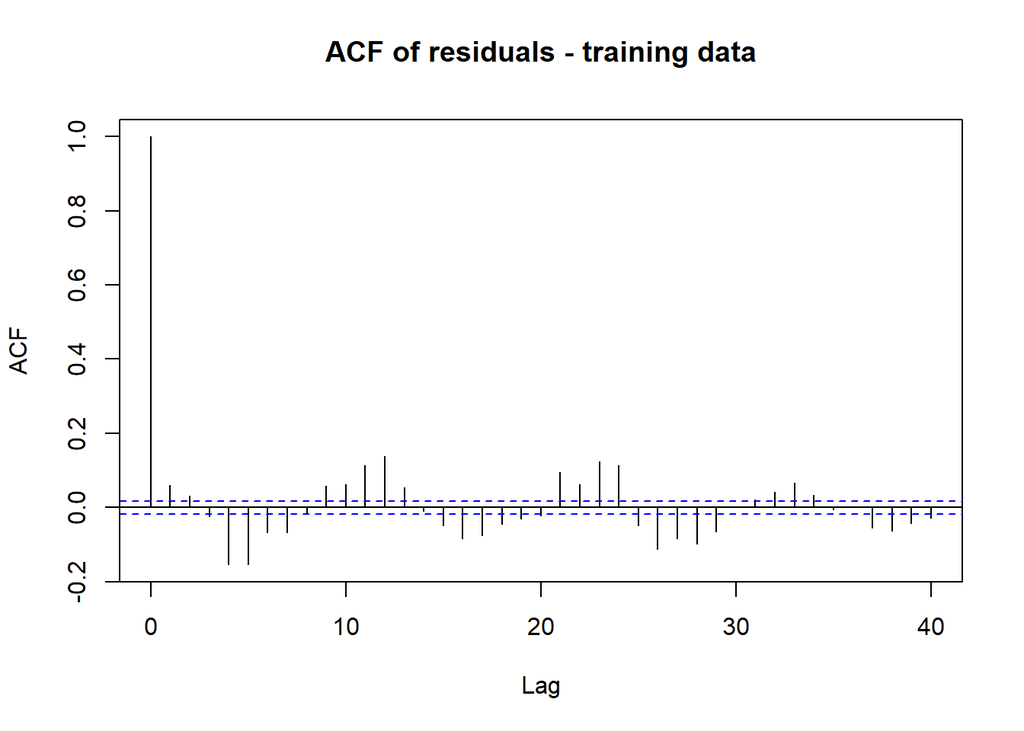

```r
#=== 8. Compute the residuals
residuals_train_lag <- y_train_lag - y_hat_train_lag
residuals_test_lag <- y_test_lag - y_hat_test_lag
  #---Plot of autocorrelation function
  acf(residuals_train_lag, main = "ACF of residuals - training data")
```

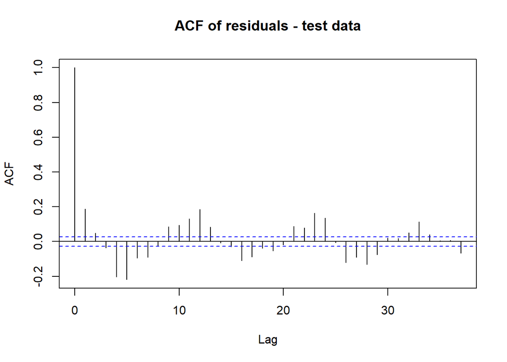

```r
  acf(residuals_test_lag, main = "ACF of residuals - test data")
```

#### 💪 Problem 4.3

Add the predictions from Problem 4.2 to the figure you created in Problem 4.1. Did the predictions improve by adding lags of the response variable?

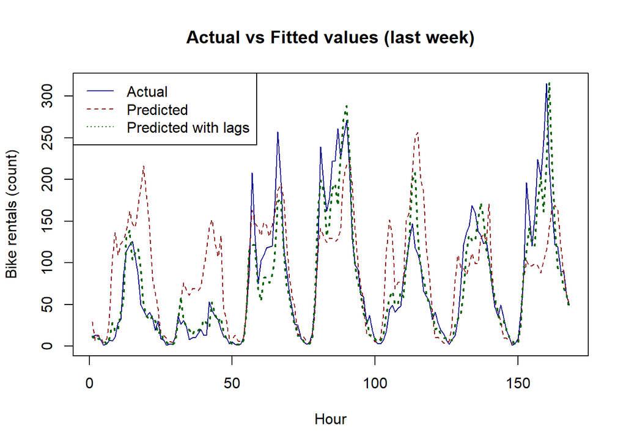

```r
#=== 1. Fitted values from problem 4.1
fitted_cnts <- exp(tail(y_alltest_hat, lastweek_idx))

#last_week_data_lag <- (nrow(bike_alldata_test_lag) - 24*7 +1 ):nrow(bike_alldata_test_lag)
#y_test_lastweek_lag <- bike_alldata_test_lag$cnt[last_week_data_lag] #true counts

#=== 2. Compute the fitted values from Problem 4.2
fitted_cnts_lag <- exp (tail(y_hat_test_lag, lastweek_idx))
#y_hat_lastweek_lag <- y_hat_cnt_lag [last_week_data_lag] #Extract last 168 fitted values
#=== 2. Add the prediction to the plot
plot_grid <- 1:lastweek_idx
plot (plot_grid, true_count, type = "l", lwd = 1, col = "darkblue",lty = 1, xlab = "Hour", ylab = "Bike rentals (count)", main = "Actual vs Fitted values (last week)")
lines (plot_grid, fitted_cnts, col ="darkred", lty = 2, lwd = 1)
lines (plot_grid, fitted_cnts_lag, col ="darkgreen", lty = 3, lwd = 2)

legend (x = "topleft", col = c("darkblue", "darkred", "darkgreen"), lty = c(1,2,3), legend = c("Actual", "Predicted", "Predicted with lags"))
```

#### 💪 Problem 4.4

Another alternative to the semi-parametric approach above is to fit a regression tree.

Using the training dataset from Problem 4.2 (that also includes lagged values of the response as features), fit a regression tree using the `tree` package. If you want, experiment with the settings to see how changing them affects the results.

```r
suppressMessages(library(tree))

#=== 1. Prepare data
  # --- Name the splines column
splines_names <- paste0("spline", 1:10)
colnames (spline_train_lag) <- splines_names
colnames (spline_test_lag) <- splines_names

  # --- Add spline columns to data
bike_data_train_lag <- cbind (bike_data_train_lag, spline_train_lag)
bike_data_test_lag <- cbind (bike_data_test_lag, spline_test_lag)

  #--- Define features for tree

features <- c ('log_cnt_lag1', 'log_cnt_lag2', 'log_cnt_lag3',
              'log_cnt_lag4',  'log_cnt_lag24',
               'yr','holiday', 'workingday', 'temp', 'atemp', 'hum','windspeed',
               'cloudy', 'light rain', 'heavy rain',
               'Mon', 'Tue', 'Wed', 'Thu', 'Fri','Sat',
               'Spring', 'Summer', 'Fall', splines_names)

  #--- Ensure valid names
colnames (bike_data_train_lag) <- make.names(colnames(bike_data_train_lag))
colnames (bike_data_test_lag) <- make.names(colnames(bike_data_test_lag))
features <- make.names (features)

#=== 2. Prepare tree data
treedata_train <- (bike_data_train_lag[, c('log_cnt', features)])
treedata_train <- na.omit(treedata_train)
treedata_test <- bike_data_test_lag[, features]

y_train_tree <- treedata_train$log_cnt
y_test_tree <- bike_data_test_lag$log_cnt

#=== 3. Set tree controls/experiment parameters
#minisize = minimum observations in a node to allow split
#mindev = minimum deviace reduction to allow split

tree_ctrl <- tree.control(nobs = nrow(treedata_train), minsize = 5, mindev = 0.001)

#=== 4.Fit the regression tree
set.seed(0)
regression_tree <- tree (log_cnt ~ ., data = treedata_train)

#=== 5. Inspect the tree
print(summary(regression_tree)) # summary
```

```
Regression tree:
tree(formula = log_cnt ~ ., data = treedata_train)
Variables actually used in tree construction:
[1] "log_cnt_lag1"  "spline10"      "spline8"       "log_cnt_lag4"
[5] "log_cnt_lag24"
Number of terminal nodes:  9
Residual mean deviance:  0.3258 = 3991 / 12250
Distribution of residuals:
    Min.  1st Qu.   Median     Mean  3rd Qu.     Max.
-3.51400 -0.34300  0.03172  0.00000  0.38000  2.33700
```

```r
#=== 6. Prediction from the tree and compute RMSE
y_hat_train_tree <- predict(regression_tree, newdata = treedata_train)
y_hat_test_tree <- predict(regression_tree, newdata = treedata_test)

RMSE_train_tree <- sqrt(mean((y_train_tree - y_hat_train_tree)^2))
RMSE_test_tree <- sqrt(mean((y_test_tree - y_hat_test_tree)^2))
cat("RMSE (Train):", RMSE_train_tree, "\n")
```

```
RMSE (Train): 0.5706015
```

```r
cat ("RMSE (Test):", RMSE_test_tree, "\n")
```

```
RMSE (Test): 0.6000504
```

#### 💪 Problem 4.5

Plot the tree structure in Problem 4.4.

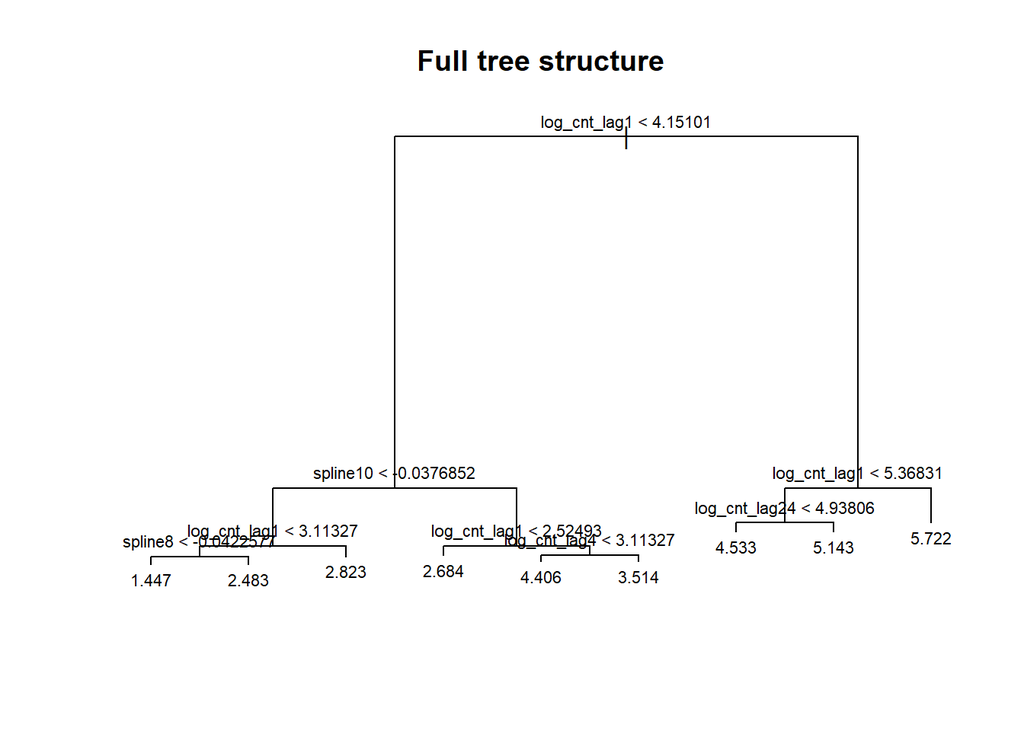

```r
plot (regression_tree)
text (regression_tree, pretty = 3, cex = 0.7)
title ("Full tree structure")
```

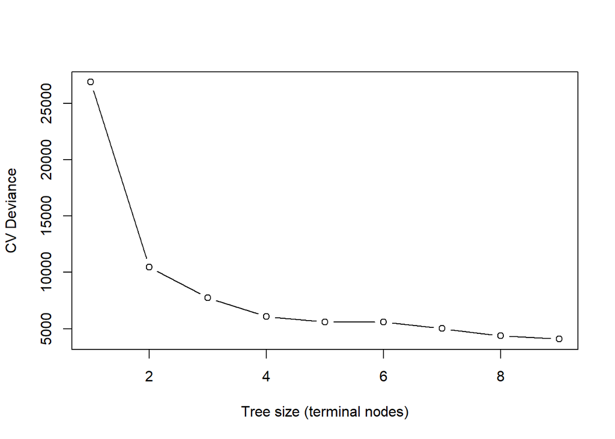

```r
#=== Optional: prune tree by specifying max depth
# Prune based on CV error to avoid overfitting
cv_tree <- cv.tree(regression_tree, K = 10)

# Keep only unique tree sizes and corresponding deviance
unique_sizes <- !duplicated(cv_tree$size)
cv_size <- cv_tree$size[unique_sizes]
cv_dev <- cv_tree$dev[unique_sizes]

# Plot
plot(cv_size, cv_dev, type='b', xlab="Tree size (terminal nodes)", ylab="CV Deviance")
```

```r
# Find optimal tree size
opt_size <- cv_size[which.min(cv_dev)]
print(opt_size)
```

```
[1] 9
```

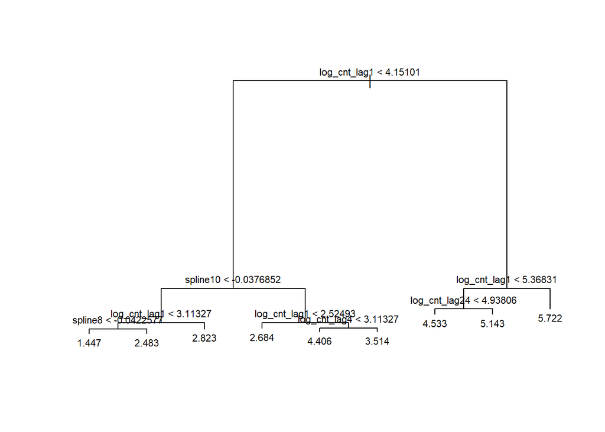

```r
# Prune the tree to optimal size
pruned_tree <- prune.tree(regression_tree, best = opt_size)
plot(pruned_tree)
text(pruned_tree, pretty=0, cex=0.7)
```

#### 💪 Problem 4.6

Add the predictions from Problem 4.4 to the figure you created in Problem 4.3. Comment on the fit of the regression tree compared to that of the semi-parametric spline approach.

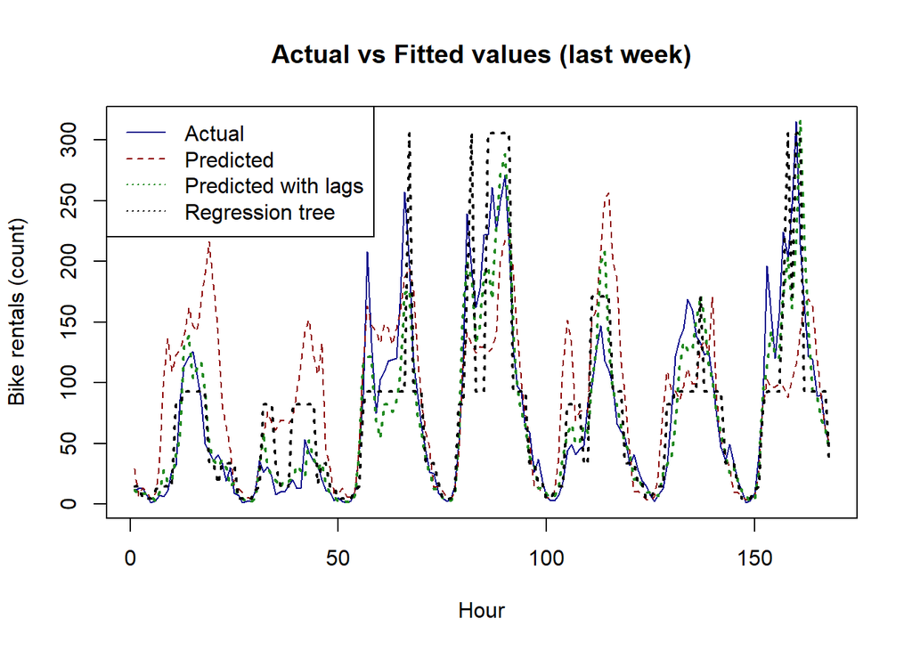

```r
#=== 1. Compute predicted values from problem 4.5
y_hat_test_tree <- predict(regression_tree, newdata = treedata_test)
fitted_cnts_tree <- exp (tail (y_hat_test_tree, lastweek_idx)) #Values for the data of last week

#last_week_data_lag <- (nrow(bike_alldata_test_lag) - 24*7 +1 ):nrow(bike_alldata_test_lag)
#y_test_lastweek_lag <- bike_alldata_test_lag$cnt[last_week_data_lag] #true count

#=== 2. Predict values for the last week
#y_hat_tree_lastweek <- predict (regression_tree, newdata = treedata_test_lastweek)
#y_hat_cnt_tree <- exp (y_hat_tree_lastweek) #Transform back to original scale

#=== 2. Add prediction to the plot
plot_grid <- 1:168
plot (plot_grid, true_count, type = "l", lwd = 1, col = "darkblue",lty = 1, xlab = "Hour", ylab = "Bike rentals (count)", main = "Actual vs Fitted values (last week)")
lines (plot_grid, fitted_cnts, col ="darkred", lty = 2, lwd = 1)
lines (plot_grid, fitted_cnts_lag, col ="forestgreen", lty = 3, lwd = 2)
lines (plot_grid, fitted_cnts_tree, col = "black", lty = 3, lwd = 2)

legend (x = "topleft", col = c("darkblue", "darkred", "forestgreen","black"), lty = c(1,2,3,3), legend = c("Actual", "Predicted", "Predicted with lags", "Regression tree"))
```

## 5. Logistic regression and decision trees for classifying spam emails (3 marks)

The dataset `spam_ham_emails.RData` consists of $n=4601$ spam ($y=1$) and ham (no spam, $y=0$) emails with corresponding 15 features[^2].

Most of the features are continuous real variables in the interval $[0, 100]$, with values corresponding to the percentage of occurrence of a specific word or character in the email. There are also a few features that capture the tendency to use many capital letters. The features are on different scales so we will standardise them to have zero mean and unit variance. The following code reads in the data (note that you have to change to the path were you stored the file!), standardises the features, and codes the response variable as a factor.

```r
rm(list=ls()) # Remove variables
cat("\014") # Clean workspace
```

```r
load(file = 'C:/Users/TSC/Desktop/UTS/Sem 1/Machine Learning/Cmp Lab 1/spam_ham_emails.RData')
Spam_ham_emails[, -1] <- scale(Spam_ham_emails[, -1])
Spam_ham_emails['spam'] <- as.factor(Spam_ham_emails['spam'] == 1) # Changing from 1->TRUE, 0->FALSE
levels(Spam_ham_emails$spam) <- c("not spam", "spam")
head(Spam_ham_emails)
```

```
      spam       over     remove   internet        free        hpl          X.
1 not spam -0.3502281 -0.2917622 -0.2625330 -0.30134485  4.2669752 -0.32987644
2     spam  1.6583607 -0.2917622  0.4106637  1.03071019 -0.2992074  0.38364598
3 not spam -0.3502281 -0.2917622 -0.2625330 -0.30134485  2.6659926 -0.32987644
4     spam  0.6358064 -0.2917622 -0.2625330 -0.30134485 -0.2992074 -0.28451505
5     spam  0.3436480  0.1936234 -0.2625330 -0.07126262 -0.2992074 -0.06996793
6     spam -0.3502281  0.9855684  0.9841276 -0.30134485 -0.2992074  0.17522878
        X..1   CapRunMax CapRunTotal        our         hp   george      X1999
1 -0.3083214 -0.17021174  0.02096274 -0.4642639  3.9791176 -0.22787  4.9900587
2  0.8751730 -0.08811470  0.01271665 -0.4642639 -0.3287789 -0.22787 -0.3234205
3 -0.3083214 -0.22665345 -0.40618481 -0.4642639 -0.3287789 -0.22787  2.7702052
4 -0.3083214 -0.09837683 -0.12416847 -0.4642639 -0.3287789 -0.22787 -0.3234205
5  0.9239769  0.40959862  0.75651413 -0.1817414 -0.3287789 -0.22787 -0.3234205
6  1.3672790 -0.17021174 -0.05655052  0.6658261 -0.3287789 -0.22787 -0.3234205
           re       edu
1  0.59185916 -0.197366
2 -0.03086294 -0.197366
3 -0.29774385 -0.197366
4 -0.29774385 -0.197366
5 -0.29774385 -0.197366
6 -0.29774385 -0.197366
```

```r
str(Spam_ham_emails)
```

```
'data.frame':   4601 obs. of  16 variables:
 $ spam       : Factor w/ 2 levels "not spam","spam": 1 2 1 2 2 2 2 1 2 1 ...
 $ over       : num  -0.35 1.658 -0.35 0.636 0.344 ...
 $ remove     : num  -0.292 -0.292 -0.292 -0.292 0.194 ...
 $ internet   : num  -0.263 0.411 -0.263 -0.263 -0.263 ...
 $ free       : num  -0.3013 1.0307 -0.3013 -0.3013 -0.0713 ...
 $ hpl        : num  4.267 -0.299 2.666 -0.299 -0.299 ...
 $ X.         : num  -0.33 0.384 -0.33 -0.285 -0.07 ...
 $ X..1       : num  -0.308 0.875 -0.308 -0.308 0.924 ...
 $ CapRunMax  : num  -0.1702 -0.0881 -0.2267 -0.0984 0.4096 ...
 $ CapRunTotal: num  0.021 0.0127 -0.4062 -0.1242 0.7565 ...
 $ our        : num  -0.464 -0.464 -0.464 -0.464 -0.182 ...
 $ hp         : num  3.979 -0.329 -0.329 -0.329 -0.329 ...
 $ george     : num  -0.228 -0.228 -0.228 -0.228 -0.228 ...
 $ X1999      : num  4.99 -0.323 2.77 -0.323 -0.323 ...
 $ re         : num  0.5919 -0.0309 -0.2977 -0.2977 -0.2977 ...
 $ edu        : num  -0.197 -0.197 -0.197 -0.197 -0.197 ...
```

The response is the first column `spam` and we will use all the other features to predict if an email is a spam or ham. Let us first inspect the fraction of spam emails in the dataset.

```r
cat("Percentage of spam:", 100*mean(Spam_ham_emails$spam == "spam"))
```

```
Percentage of spam: 39.40448
```

We now split the data using the `createDataPartition()` function in the `caret` package. The default method in `caret` is stratified sampling, which keeps the same fraction of spam and ham in both the training and test datasets. We use 75% of the data for training and 25% for testing.

```r
set.seed(1234)
suppressMessages(library(caret))
train_obs <- createDataPartition(y = Spam_ham_emails$spam, p = .75, list = FALSE)
train <- Spam_ham_emails[train_obs, ]
test <- Spam_ham_emails[-train_obs, ]
# Confirm both training and test are balanced with respect to spam emails
cat("Percentage of training data consisting of spam emails:",
              100*mean(train$spam == "spam"))
```

```
Percentage of training data consisting of spam emails: 39.40887
```

```r
cat("Percentage of test data consisting of spam emails:",
              100*mean(test$spam == "spam"))
```

```
Percentage of test data consisting of spam emails: 39.3913
```

The following code fits a logistic regression on the training data using the `glm()` function, predicts the test data following the rule if $\mathrm{Pr}(y=1|\mathbf{x})>0.5 \Rightarrow y=1$, and computes the confusion matrix using the `caret` package.

```r
glm_fit <- glm(spam ~ ., family = binomial, data = train)
y_prob_hat_test <- predict(glm_fit, newdata = test, type = "response")
threshold <- 0.5 # Predict spam if probability > threshold
y_hat_test <- as.factor(y_prob_hat_test > threshold)
levels(y_hat_test) <- c("not spam", "spam")
confusionMatrix(data = y_hat_test, test$spam, positive = "spam")
```

```
Confusion Matrix and Statistics

          Reference
Prediction not spam spam
  not spam      658   65
  spam           39  388

               Accuracy : 0.9096
                 95% CI : (0.8915, 0.9255)
    No Information Rate : 0.6061
    P-Value [Acc > NIR] : < 2e-16

                  Kappa : 0.8087

 Mcnemar's Test P-Value : 0.01423

            Sensitivity : 0.8565
            Specificity : 0.9440
         Pos Pred Value : 0.9087
         Neg Pred Value : 0.9101
             Prevalence : 0.3939
         Detection Rate : 0.3374
   Detection Prevalence : 0.3713
      Balanced Accuracy : 0.9003

       'Positive' Class : spam
```

#### 💪 Problem 5.1

Reconstruct the confusion matrix for the test data without using the `confusionMatrix()` function.

```r
y_true <- as.character(test$spam)
#=== 1. Predicted labels using threshold
y_pred <- ifelse (y_prob_hat_test > threshold, "spam", "not spam")

#=== 2. Calculate the TP, TN, FP, FN
TP <- sum (y_pred == "spam" & y_true == "spam")
TN <- sum (y_pred == "not spam" & y_true == "not spam" )
FP <- sum (y_pred == "spam" & y_true == "not spam")
FN <- sum (y_pred == "not spam" & y_true == "spam")

#=== 3. Build confusion matrix
conf_matrix <- matrix(c (TN, FN, FP, TP), nrow = 2, byrow = TRUE, dimnames = list ("Predicted" = c ("not spam", "spam"), "Actual" = c ("not spam", "spam")))

print("Confusion Matrix (Actual vs Predicted):")
```

```
[1] "Confusion Matrix (Actual vs Predicted):"
```

```r
print(conf_matrix)
```

```
          Actual
Predicted  not spam spam
  not spam      658   65
  spam           39  388
```

#### 💪 Problem 5.2

Compute the accuracy, precision, sensitivity (recall), and specificity without using the `confusionMatrix()` function. Explain these four concepts in the context of the spam filter.

```r
#=== 1. Compute the accuracy, precision, sensitivity (recall) and specificity

accuracy    <- (TP + TN) / (TP + TN + FP + FN)
precision   <- TP / (TP + FP)
recall      <- TP / (TP + FN)    # sensitivity
specificity <- TN / (TN + FP)

metrics_log <- data.frame(
  Metrics = c("Accuracy", "Precision", "Recall (Sensitivity)", "Specificity"),
  Logistic  = c(accuracy, precision, recall, specificity)
)
metrics_log$Logistic <- round(metrics_log$Logistic, 4)
print(metrics_log, row.names = FALSE)
```

```
              Metrics Logistic
             Accuracy   0.9096
            Precision   0.9087
 Recall (Sensitivity)   0.8565
          Specificity   0.9440
```

```r
#=== 2. Explain the four concepts
```

#### 💪 Problem 5.3

Compute the receiver operating characteristic (ROC) curve using the `pROC`. Explain in detail what the ROC curve shows.

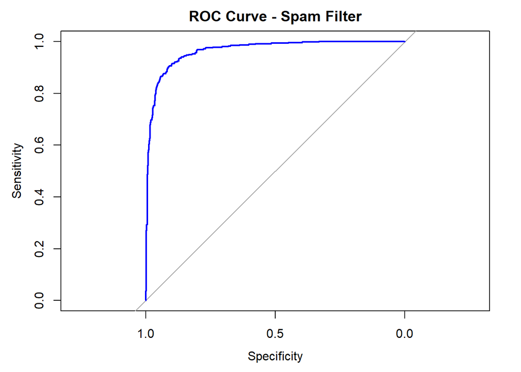

```r
# Load required library
suppressMessages(library(PRROC))
suppressMessages(library(pROC))
#=== 1. Compute the ROC
ref <- factor(test$spam, levels = c("not spam", "spam"))
roc_cal <- roc(response = ref,
               predictor = y_prob_hat_test,
               levels = c("not spam", "spam"),
               direction = "<") #higher scores correspond to the positive class

#=== 2. Plot the ROC curve
plot(roc_cal,
     main = "ROC Curve - Spam Filter",
     col = "blue",
     lwd = 2)
```

```r
#=== 3. Compute the AUC
auc (roc_cal)
```

```
Area under the curve: 0.9651
```

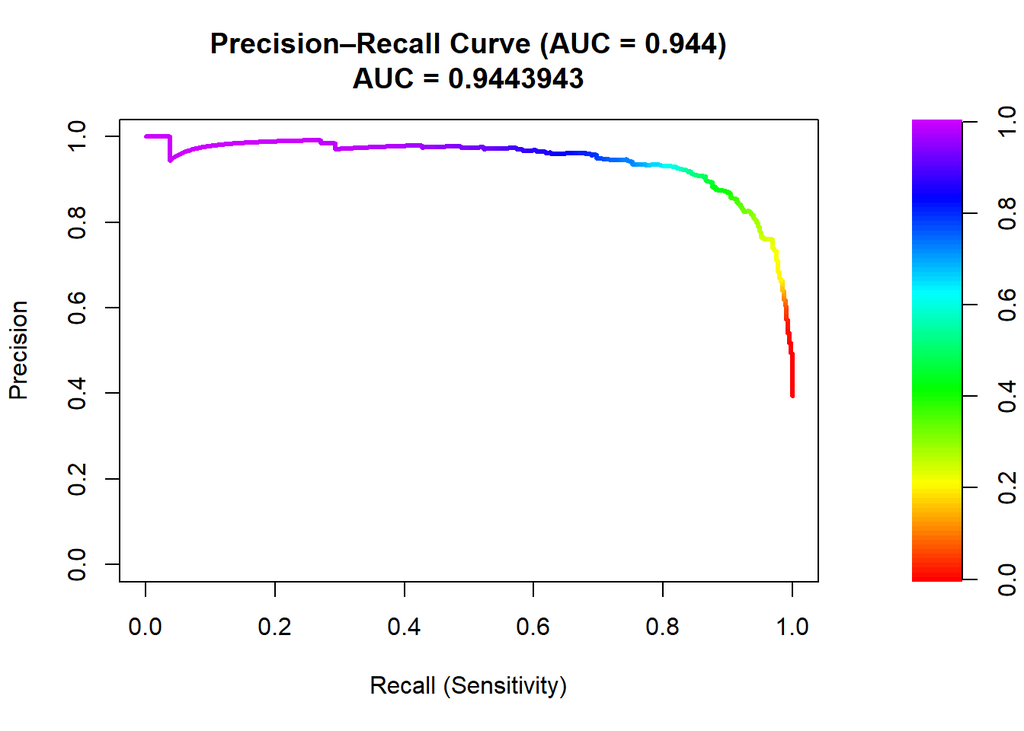

```r
#=== Optional
# 1) Convert actual labels to numeric: spam = 1, not spam = 0
y_true <- ifelse(test$spam == "spam", 1, 0)

# 2) Compute precision-recall curve points
pr <- pr.curve(scores.class0 = y_prob_hat_test[y_true == 1],
               scores.class1 = y_prob_hat_test[y_true == 0],
               curve = TRUE)

# 3) Plot Precision–Recall curve
plot(pr,
     main = sprintf("Precision–Recall Curve (AUC = %.3f)", pr$auc.integral),
     xlab = "Recall (Sensitivity)",
     ylab = "Precision")
```

```r
#=== 3. Explain in details
```

#### 💪 Problem 5.4

Using the training dataset, fit a decision tree (classification tree) using the `tree` package with the default settings. How does this classifier perform on the test dataset compared to the logistic classifier?

```r
suppressMessages(library(tree))
suppressMessages(library(caret))

#=== 1. Fit the tree
set.seed (0)
tree_classification <- tree(spam ~., data = train)

y_hat_tree <- predict (tree_classification, newdata = test, type = "class")

ref <- factor (test$spam, levels = c ("not spam", "spam"))

#=== 2. Compute the confusion matrix

conf_matrix_tree <- confusionMatrix(data = y_hat_tree, reference = ref, positive = "spam")
  #--- Extract key metrics
  ext_metrics <- function (conf_matrix_tree) {
    data.frame ( c(
                Accuracy = as.numeric (conf_matrix_tree$overall["Accuracy"]),
                Precision = as.numeric(conf_matrix_tree$byClass["Pos Pred Value"]),                 Recall= as.numeric (conf_matrix_tree$byClass["Sensitivity"]),                      Specificity = as.numeric (conf_matrix_tree$byClass["Specificity"])))}

  metrics_tree <- ext_metrics(conf_matrix_tree)
  metrics_tree <- data.frame (
                  Metrics = c("Accuracy", "Precision", "Recall (Sensitivity)", "Specificity"),
                  DecisionTree = unname (metrics_tree),
                  row.names = NULL )


#=== 3. Compare with metrics of logistic classifier
comparison <- merge (metrics_tree, metrics_log, by = "Metrics", all = TRUE )
comparison$Logistic <- round (comparison$Logistic, 4)
comparison$DecisionTree <-round (comparison$DecisionTree, 4)

print (comparison)
```

```
               Metrics DecisionTree Logistic
1             Accuracy       0.9035   0.9096
2            Precision       0.8958   0.9087
3 Recall (Sensitivity)       0.8543   0.8565
4          Specificity       0.9354   0.9440
```

#### 💪 Problem 5.5

Plot the tree structure in Problem 5.4.

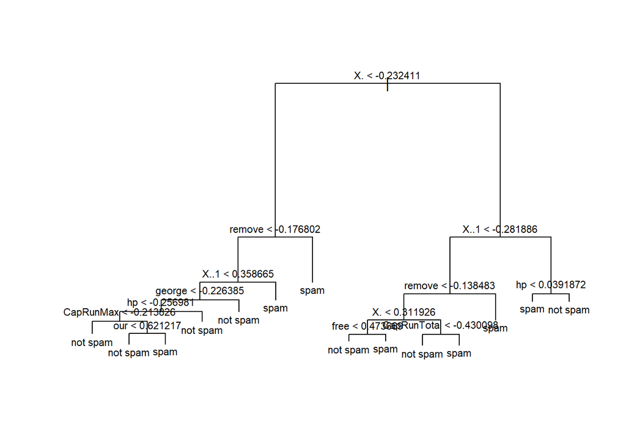

```r
plot (tree_classification)
text (tree_classification, pretty = 0, cex = 0.7)
```

```r
print (summary(tree_classification))
```

```
Classification tree:
tree(formula = spam ~ ., data = train)
Variables actually used in tree construction:
[1] "X."          "remove"      "X..1"        "george"      "hp"
[6] "CapRunMax"   "our"         "free"        "CapRunTotal"
Number of terminal nodes:  14
Residual mean deviance:  0.4606 = 1583 / 3437
Misclassification error rate: 0.08056 = 278 / 3451
```

## Footnotes

[^1]: The original data come from this [source](https://archive.ics.uci.edu/dataset/275/bike+sharing+dataset).
[^2]: The original data come from this [source](https://archive.ics.uci.edu/ml/datasets/spambase). The dataset used here includes a subset of the 57 original features.